# Iris Prediction App

## About The Iris Prediction App

This app uses the iris data set to predict sepal length based on the following inputs:

- Sepal width (number input)
- Petal length (number input)
- Petal width (number input)
- Species (radio button input)

In addition, there is a plot showing the values in the data set (coloured by species) and the predicted value. The Y-axis is *always* sepal length; the X-axis can be changed to sepal width, petal length, or petal width.

Once the **Go!** button is clicked, the predicted value is displayed, and the plot is updated.

## Prediction Model

The prediction model used in the app is quite simple:

```
Sepal.Length ~ Sepal.Width + Petal.Length + Petal.Width + Species
```

The default values when the app is first opened are:

- sepal width = 3.5
- petal length = 1.4
- petal width = 0.2
- species = setosa

## Default Prediction

The default predicted value for sepal length when the app is opened is:

```r
mod <- lm(Sepal.Length ~ Sepal.Width +
            Petal.Length + Petal.Width +
            Species, data = iris)

pred <- predict(mod,
                newdata = data.frame(
                  Sepal.Width = 3.5,
                  Petal.Length = 1.4,
                  Petal.Width = 0.2,
                  Species = 'setosa'))

unname(round(pred, 1))
```

```
[1] 5
```

## Default Plot

Based on the default values listed above, as well as the default choice of sepal width being the x axis for the plot, the default plot for the app is shown below.

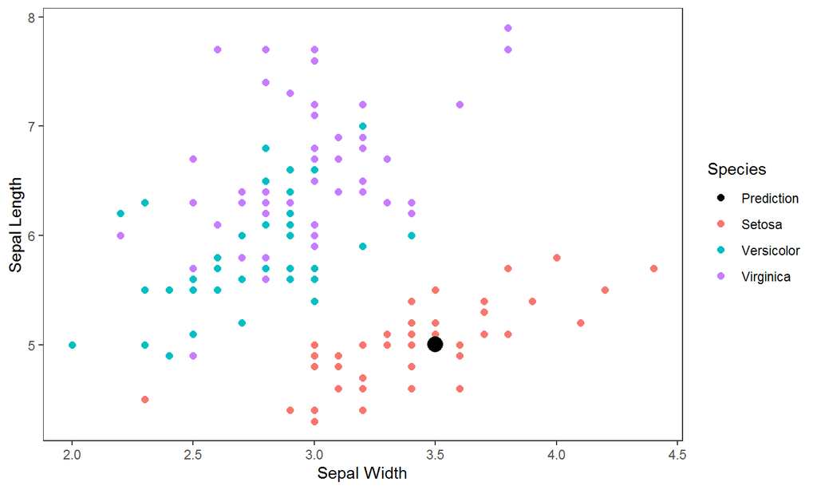